# Getting Started

`threeBrain` is an R package that renders `FreeSurfer` or `AFNI/SUMA` files in the modern web browsers. The goal is to provide 3D viewers that are **powerful**, **interactive**, **easy-to-share**.

## Directory Setup

The basic setup of a typical subject folder should look like this:

```
Project Directory
  └─Subject code
    ├─mri   - Atlas, T1 and/or CT image files (*.mgz, transforms, ...)
    ├─surf  - FreeSurfer surface files (pial, sulc, ...)
    ├─SUMA  - (Optional) SUMA standard 141 surfaces (std.141.*)
    └─...   - Other files
```

If you are using `FreeSurfer` to generate MRI reconstruction, then you are all set! For `AFNI/SUMA` users, please place your `SUMA` folder under subject folder.

If you don’t have any `FreeSurfer` folders, you can download a sample archive from [here](https://github.com/dipterix/threeBrain-sample/releases), choose `N27-complete.zip`, and extract to your download directory. Once extracted, you will have a `N27` subject folder in the `~/Downloads/` directory. The directory tree looks exactly the same as described above.

In the following context, I will use `~/Downloads/N27` as an example

## Generate Viewer Object

```r
library(threeBrain)
subject_code <- "N27"
subject_path <- "~/Downloads/N27"
brain <- freesurfer_brain2(subject_path, subject_code)
print(brain)
```

```
#> Subject - N27
#> Transforms:
#>
#> - FreeSurfer TalXFM [from scanner to MNI305]:
#>        [,1]    [,2]    [,3]    [,4]
#> [1,] 0.9692 -0.0029 -0.0134 -0.1638
#> [2,] 0.0062  0.9685  0.0492 -2.0717
#> [3,] 0.0145  0.0276  0.9541  0.1361
#> [4,] 0.0000  0.0000  0.0000  1.0000
#>
#> - Torig [Voxel CRS to FreeSurfer origin, vox2ras-tkr]
#>      [,1] [,2] [,3] [,4]
#> [1,]   -1    0    0  128
#> [2,]    0    0    1 -128
#> [3,]    0   -1    0  128
#> [4,]    0    0    0    1
#>
#> - Norig [Voxel CRS to Scanner center, vox2ras]
#>      [,1] [,2] [,3]   [,4]
#> [1,]   -1    0    0  128.5
#> [2,]    0    0    1 -145.5
#> [3,]    0   -1    0  146.5
#> [4,]    0    0    0    1.0
#>
#> - Scanner center relative to FreeSurfer origin
#> [1]  -0.5  17.5 -18.5
#>
#> - FreeSurfer RAS to MNI305, vox2vox-MNI305
#>        [,1]    [,2]    [,3]      [,4]
#> [1,] 0.9692 -0.0029 -0.0134   0.12365
#> [2,] 0.0062  0.9685  0.0492 -18.10715
#> [3,] 0.0145  0.0276  0.9541  17.31120
#> [4,] 0.0000  0.0000  0.0000   1.00000
#> Surface information (total count 1)
#>   pial [ std.141 ]
#> Volume information (total count 1)
#>   T1
```

If this is the first time, it might take a while to import and generate cache files.

## Visualization

Visualizing the viewer is simply just one line.

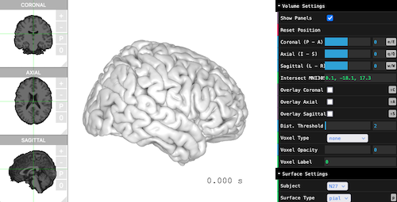

```r
brain$plot()
```

## Surface, Volume, Atlas

By default, the viewers only load the following information. Only the `pial` surfaces are mandatory, other files are optional.

- T1 (MR images) and transforms (optional)
  - `mri/brain.finalsurfs.mgz`
  - `mri/transforms/talairach.xfm`
- `pial` (mandatory) and `sulc` (optional)
  - `surf/*h.pial` or `SUMA/std.141.*h.pial[.asc|gii]`
  - `surf/*h.sulc` or `SUMA/std.141.*h.sulc.1D`
- `aparc+aseg` (optional)
  - `mri/aparc+aseg.mgz`

The T1 image is automatically detected if `brain.finalsurfs.mgz` is missing. The following alternatives are `brainmask.mgz`, `brainmask.auto.mgz`, `T1.mgz`.

To load more than one surfaces, please specify the surface types when loading the viewer. The available surface types are:

- `pial` - (default)
- `smoothwm`, `white` - (smoothed) white matter
- `inflated`, `sphere` - inflated surfaces
- `pial-outer-smoothed` - (‘FreeSurfer’-only) smoothed surface tightly wrapping the pial surface
- `inf_200` - (‘SUMA’-only) inflated pial surface

The atlas type can be selected from `aparc+aseg`, `aparc.a2009s+aseg`, `aparc.DKTatlas+aseg`, or `aseg`. To load a specific atlas, please make sure the corresponding file exists in `mri/`. For example, `mri/aseg.mgz`.

The following example loads `pial` and `smoothwm`, with `aseg` as atlas. The viewer shows ‘Coronal’ plane, smoothed white matter, ‘Ventricle’, and ‘Cerebellum’ all together in one scene.

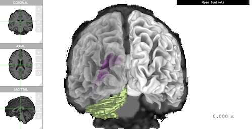

```r
brain <- freesurfer_brain2(
  subject_path, subject_code,
  surface_types = c('pial', 'smoothwm'),
  atlas_types = 'aseg')

brain$plot(
  controllers = list(
    "Voxel Type" = "aseg",
    "Voxel Label" = "4,5,6,7",
    "Surface Type" = "smoothwm",
    "Left Opacity" = 0.4,
    "Overlay Coronal" = TRUE
  ),
  control_display = FALSE,
  camera_pos = c(0, -500, 0)
)
```